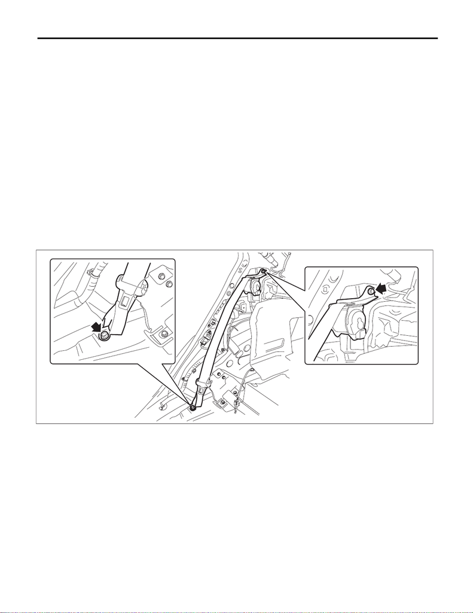

SB-24

Rear Seat Belt

SEAT BELT SYSTEM

6. Rear Seat Belt

A: REMOVAL

1. SEAT BELT OUTER - REAR RH & LH

CAUTION:

• Airbag system satellite safing sensor is located in the lower of the rear seat cushion center. Before

removing the rear seat, refer to “CAUTION” of “General Description” in “AIRBAG SYSTEM” section.

<Ref. to AB-9, CAUTION, General Description.>

• The airbag system is fitted with a backup power supply. After disconnecting the battery ground ca-

ble, the airbag may operate if you do not wait for 60 seconds before starting the service of airbag sys-

tem.

1) Turn the ignition switch to OFF.

2) Disconnect the ground cable from battery and wait for at least 60 seconds before starting work. <Ref. to

NT-5, BATTERY, NOTE, Note.>

NOTE:

For models other than STI model, disconnect the ground terminal from battery sensor.

3) Remove the rear seat cushion assembly. <Ref. to SE-29, REMOVAL, Rear Seat.>

4) Remove the cover side sill - rear INN and the trim panel - center pillar LWR. (On the side where seat belt

assembly is removed) <Ref. to EI-81, REMOVAL, Lower Inner Trim.>

5) Remove the bolts, and remove the seat belt outer - rear.

2. SEAT BELT - REAR SHOULDER CTR

CAUTION:

• Airbag system satellite safing sensor is located in the lower of the rear seat cushion center. Before

removing the rear seat, refer to “CAUTION” of “General Description” in “AIRBAG SYSTEM” section.

<Ref. to AB-9, CAUTION, General Description.>

• The airbag system is fitted with a backup power supply. After disconnecting the battery ground ca-

ble, the airbag may operate if you do not wait for 60 seconds before starting the service of airbag sys-

tem.

1) Turn the ignition switch to OFF.

2) Disconnect the ground cable from battery and wait for at least 60 seconds before starting work. <Ref. to

NT-5, BATTERY, NOTE, Note.>

NOTE:

For models other than STI model, disconnect the ground terminal from battery sensor.

3) Remove the rear seat cushion assembly. <Ref. to SE-29, REMOVAL, Rear Seat.>

SB-00492

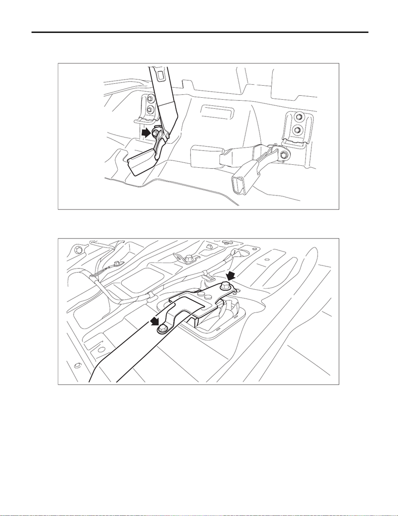

SB-25

Rear Seat Belt

SEAT BELT SYSTEM

4) Remove the side sill cover - rear INN, trim panel - rear pillar UPR, and trim panel - rear pillar LWR on the

RH and LH sides. <Ref. to EI-89, REMOVAL, Rear Quarter Trim.>

5) Remove the bolts, and remove the lower anchor of the seat belt - rear shoulder CTR.

6) Remove the high-mounted stop light. <Ref. to LI-58, REMOVAL, High-mounted Stop Light.>

7) Remove the trim panel - rear shelf assembly. <Ref. to EI-92, REMOVAL, Rear Shelf Trim.>

8) Remove the bolts, and remove the seat belt - rear shoulder CTR.

EI-03459

SB-00602

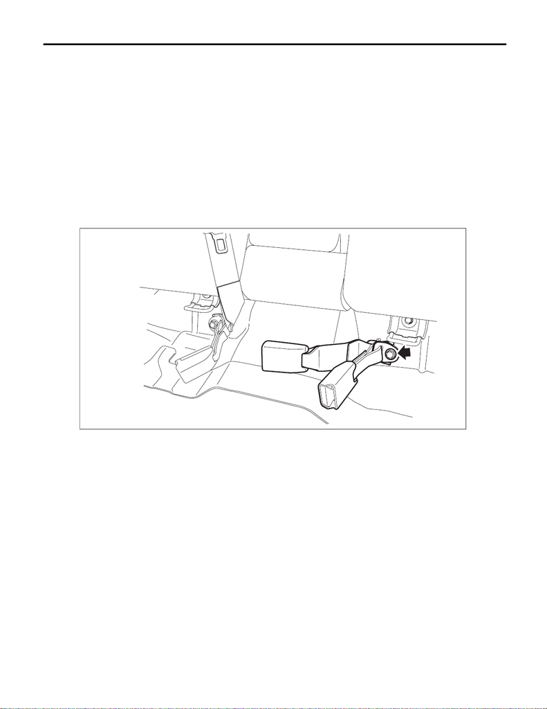

SB-26

Rear Seat Belt

SEAT BELT SYSTEM

3. SEAT BELT - CTR RH AND LH

CAUTION:

• Airbag system satellite safing sensor is located in the lower of the rear seat cushion center. Before

removing the rear seat, refer to “CAUTION” of “General Description” in “AIRBAG SYSTEM” section.

<Ref. to AB-9, CAUTION, General Description.>

• The airbag system is fitted with a backup power supply. After disconnecting the battery ground ca-

ble, the airbag may operate if you do not wait for 60 seconds before starting the service of airbag sys-

tem.

1) Turn the ignition switch to OFF.

2) Disconnect the ground cable from battery and wait for at least 60 seconds before starting work. <Ref. to

NT-5, BATTERY, NOTE, Note.>

NOTE:

For models other than STI model, disconnect the ground terminal from battery sensor.

3) Remove the rear seat cushion assembly. <Ref. to SE-29, REMOVAL, Rear Seat.>

4) Remove the bolts, and remove the seat belt - CTR RH and LH.

B: INSTALLATION

1. SEAT BELT OUTER - REAR RH & LH

1) Before installation, perform a unit inspection of retractor. <Ref. to SB-28, INSPECTION, Rear Seat Belt.>

2) Install the seat belt outer - rear.

CAUTION:

• During installation, make sure that the seat belts are not twisted.

• After installation, make sure that the seat belts are smoothly extended and wound.

Tightening torque:

Refer to “COMPONENT” of “General Description” for the tightening torque. <Ref. to SB-3, REAR

SEAT BELT, COMPONENT, General Description.>

3) Install the trim panel - rear pillar LWR, trim panel - rear pillar UPR, and cover side sill - rear INN.

4) Install the rear seat cushion assembly.

5) Connect the battery ground terminal. <Ref. to NT-5, BATTERY, NOTE, Note.>

NOTE:

For models other than STI model, connect the ground terminal to battery sensor.

6) After installation, check the following points.

• The seat belt is not twisted.

• The seat belt can be pulled out and retracted smoothly.

SB-00600

[figure not shown]

SB-27

Rear Seat Belt

SEAT BELT SYSTEM

2. SEAT BELT - REAR SHOULDER CTR

1) Install the retractor of seat belt - rear shoulder CTR.

Tightening torque:

Refer to “COMPONENT” of “General Description” for the tightening torque. <Ref. to SB-3, REAR

SEAT BELT, COMPONENT, General Description.>

2) Install the trim panel assembly - rear shelf.

3) Install the high-mounted stop light.

4) Install the lower anchor of seat belt - rear shoulder CTR.

CAUTION:

• During installation, make sure that the seat belts are not twisted.

• After installation, make sure that the seat belts are smoothly extended and wound.

Tightening torque:

30 N·m (3.1 kgf-m, 22.1 ft-lb)

5) Install the trim panel - rear pillar LWR, trim panel - rear pillar UPR, and cover side sill - rear INN.

6) Install the rear seat cushion assembly.

7) Connect the battery ground terminal. <Ref. to NT-5, BATTERY, NOTE, Note.>

NOTE:

For models other than STI model, connect the ground terminal to battery sensor.

8) After installation, check the following points.

• The seat belt is not twisted.

• The seat belt can be pulled out and retracted smoothly.

3. SEAT BELT - CTR RH AND LH

1) Install the seat belt - CTR RH/LH.

Tightening torque:

30 N·m (3.1 kgf-m, 22.1 ft-lb)

2) Install the rear seat cushion assembly.

3) Connect the battery ground terminal. <Ref. to NT-5, BATTERY, NOTE, Note.>

NOTE:

For models other than STI model, connect the ground terminal to battery sensor.

4) After installation, check the following points.

• The seat belt is not twisted.

• The seat belt buckle is pulled out properly, and seat belt engagement can be performed smoothly.

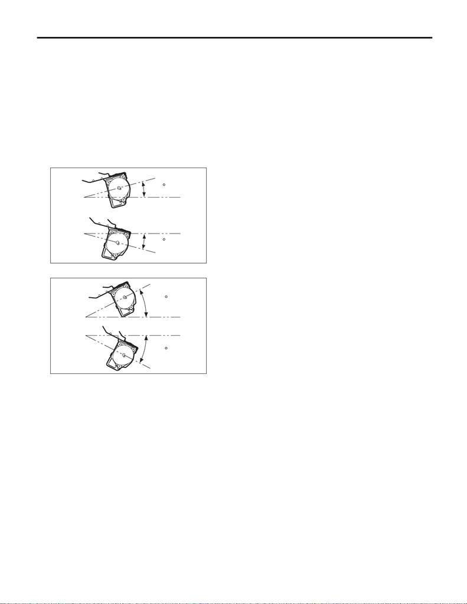

SB-28

Rear Seat Belt

SEAT BELT SYSTEM

C: INSPECTION

1. VISUAL INSPECTION

Check for the following, and replace with new parts if necessary.

• Seat belt is slackened, bent or worn.

• Seat belt is abnormally wound or extended.

• Seat belt inner - rear is deformed or damaged.

• Seat belt buckle cannot be engaged properly.

2. ELR LOCK MECHANISM INSPECTION

1) Hold the retractor upright (as installed in the vehicle) and check the ELR lock mechanism.

2) Tilt the retractor from the upright posture and check the following points.

• It does not lock if the inclination angle is 15° or less.

• It remains locked if the inclination angle is 27° or more.

3) If the ELR lock mechanism does not operate properly, replace the seat belt outer - rear with a new part.

SB-00485

15

15

SB-00486

27

27